# Reproducible Research with R’s knitr package

July 22, 2015

## Outline

1. Introduction (Ben)
2. Example and workflow (Stephanie)
3. Getting fancy (Thomas)

[figure not shown]

## Introduction

1. **What** is reproducible research?
2. **Why** reproducible research?
3. **How** to do reproducible research?

[figure not shown]

## What is reproducible research?

It's where we're all headed…

- Journal mandates
  - [Transparency and Openness Promotion (TOP) Guidelines](http://centerforopenscience.org/top/)
  - As of 2015-07-08, 115 [journal signatories](http://centerforopenscience.org/top/#journals)
- Funding mandates (NIH)
  - [Principles and Guidelines for Reporting Preclinical Research (*NIH*)](http://www.nih.gov/science/reproducibility/principles-guidelines.htm)
  - [Policy: NIH plans to enhance reproducibility (*Nature*)](http://www.nature.com/news/policy-nih-plans-to-enhance-reproducibility-1.14586)
- Mainstream press
  - [Journal Science releases guidelines for publishing scientific studies (*NY Times*)](http://www.nytimes.com/2015/06/26/science/journal-science-releases-guidelines-for-publishing-scientific-studies.html)
  - [Trouble at the lab (*The Economist*)](http://www.economist.com/news/briefing/21588057-scientists-think-science-self-correcting-alarming-degree-it-not-trouble)

## What is reproducible research?

[Transparency and Openness Promotion (TOP) Guideline's](http://centerforopenscience.org/top/) 8 standards:

1. Citation standards
2. Data transparency
3. **Analytic methods (code) transparancy**
4. Research materials transparency
5. Design and analysis transparency
6. Preregistration of studies
7. Preregistration of anlaysis plans
8. Replication

## What is reproducible research?

- Reproducible research is the idea that data analyses… **are published with their data and software code** so that others may verify the findings and build upon them
- Reproducibility makes an analysis more useful to others because the data and **code that actually conducted the analysis are available**

RR is **open sourcing** your project

[figure not shown]

## Why reproducible research?

One of the most effective ways to promote high-quality science is to create free open-source tools that give scientists easier and cheaper ways to incorporate transparency into their daily workflow:

- from **open lab notebooks**,
- to software that tracks every version of a data set (topic for another day),
- to **dynamic document generation**

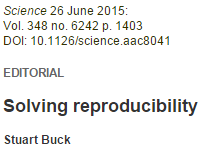

## Why reproducible research?

Reproducibility practices and reward systems

- Important to **reward scientists on the basis** of good quality of research and documentation, and **reproducibility of results**, rather than statistical significance
- Statistical shops could adopt software systems that **encourage accuracy and reproducibility of their software scripts** [e.g., *knitr*]
- **Public availability** of raw data and **complete scripts of statistical analyses** could be required by journals and funding agencies sponsoring new research — e.g., as the IOM recommended in a report on omics

[figure not shown]

## Why reproducible research?

[figure not shown]

## How to do reproducible research?

Almost reproducible research pipeline

[figure not shown]

## How to do reproducible research?

Fully reproducible research pipeline

[figure not shown]

## How to do reproducible research?

Now, some examples…